# Practical Machine Learning

Waleed Hassan

2014-09-21

## Overlook Data

```r
library(caret)
data = read.csv('pml-training.csv')[, -1]
intrain <- createDataPartition(y= data$classe, p=0.7, list= F)
training = data[intrain,]
testing = data[-intrain,]
### divide data into training and test sets
```

As we are going to predict the `classe` variable, let’s have a look at its emprical distribution in the training data:

```r
table(training$classe);
```

```
   A    B    C    D    E
3906 2658 2396 2252 2525
```

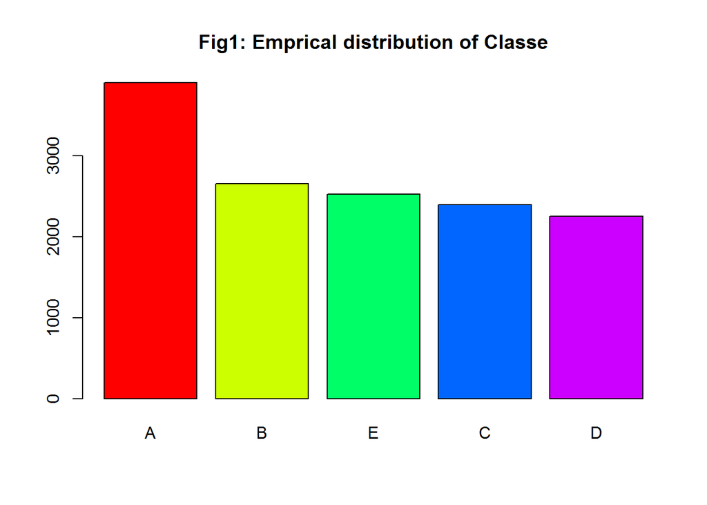

```r
barplot(sort(table(training$classe), decreasing = T),
        col=rainbow(5), main='Fig1: Emprical distribution of Classe')
```

It’s almost evenly distributed, except that the group `A` is much more than other groups.

## Preprocessing

After have a look at the data, before build a model we should do some prepocess, which need us to look explore the data deeper.

### Near Zore Variables

At the beginning, explore whether there are some `near zero variables` in the predictors, namely predictors that have one unique value (i.e. are zero variance predictors) or predictors that are have both of the following characteristics: they have very few unique values relative to the number of samples and the ratio of the frequency of the most common value to the frequency of the second most common value is large.

```r
zeroVar = nearZeroVar(training)
training = training[, -c(zeroVar)]
testing = testing[, -c(zeroVar)]
```

Here, I simply use `nearZeroVar` function in the `caret` package, and remove the returned column. Then the training have 103 column left.

### Missing values

```r
require(plyr)
miss_var = as.vector(as.matrix(colwise(function(x) any(is.na(x)))(training)))
train_data = training[, !miss_var]
test_data = testing[, !miss_var]
```

## Modeling

After have overlook and preprocess thes data, it’s time to build a model.As there are many missing values in the dataset, I choose the Random Forest model, which is much more powful than simple trees.

```r
factor_var = sapply(train_data, class) == 'factor'
train_data[, !factor_var] = colwise(as.numeric)(train_data[, !factor_var])
test_data[, !factor_var] = colwise(as.numeric)(test_data[, !factor_var])

tag = rep(c('train', 'test'), c(nrow(train_data), nrow(test_data)))
colnames(test_data) = colnames(train_data)
test_data$classe = 'A'
all_data = rbind(train_data, test_data)
set.seed(123)
require(randomForest)
model = randomForest(classe ~ ., data=all_data[tag == 'train', ])
model
```

```
Call:
 randomForest(formula = classe ~ ., data = all_data[tag == "train",      ])
               Type of random forest: classification
                     Number of trees: 500
No. of variables tried at each split: 7

        OOB estimate of  error rate: 0.1%
Confusion matrix:
     A    B    C    D    E class.error
A 3906    0    0    0    0    0.000000
B    2 2655    1    0    0    0.001129
C    0    2 2392    2    0    0.001669
D    0    0    5 2246    1    0.002664
E    0    0    0    1 2524    0.000396
```

As we can see, the OOB(out of bag) estimate of error rate is 0.001. This is also the expected out of sample error.

## Predict

At last, given the test data, make a prediction.

```r
pre = predict(model, newdata=all_data[tag == 'test', ])
as.character(pre)
```

[output not shown]

[output cut: 332 more lines]